# Gapminder_investigation

## Introduction

### Dataset Description

Dans ce projet, je vais travailler sur la base de données fournie par Gapminder WorldIn. Gapminder nous a fournie plusieur indicateur sur le mode de vie de plusieurs pays dans le monde je vais donc devoir choisir quelques'un d'entre eux et travailler avec pour repondre a mes questions. Les indicateurs choisis sont les suivants :

- births attended by skilled health staff percent of total est une base de données qui pourcentage de accouchements assistés par du personnel de santé qualifié.
- females aged 15plus employment rate percent : Pourcentage de la population féminine, groupe d'âge de 15 ans et plus, qui a occupé un emploi au cours de l'année donnée.
- Maternal mortality ratio.
- newborn_mortality_rate_per_1000 : Enfants décédés au cours des 28 premiers jours pour 1000 naissances vivantes

### Question(s) for Analysis

Les quesitons auquelles je vais essayer de repondre dans ce projet sont les suivantes:

- Le taux de femme qui travail a t'il augmenté de 2005 a 2015 ?
- Quelles sont les caracteristique qui font qu'un pays a un taux de mortalité natale plus élevè que d'autres ?
- Le taux de femmes qui travail affect-il le taux moyen de mort natale??
- Le taux de mortalité Maternel affect-il le taux de mortalité natal?
- Le taux de mortalité Maternel a t-il une relation avec les acouchements non supervisé par des pro?

```python
import pandas as pd
import numpy as np
import seaborn as sns
import matplotlib.pyplot as plt
import warnings
warnings.filterwarnings('ignore')
%matplotlib inline

colors = sns.color_palette('pastel')[0:5]
```

## Fonction et Variable global

```python
labels = ['2005','2006','2007','2008','2009','2010','2011','2012','2013','2014','2015']
```

## Data Wrangling

#### I/- Importé les bases de données

```python
# Load your data and print out a few lines. Perform operations to inspect data
df_females_employment = pd.read_csv('BDD/females_aged_15plus_employment_rate_percent.csv')

df_newborn_mortality = pd.read_csv('BDD/newborn_mortality_rate_per_1000.csv')

df_health_staff = pd.read_csv('BDD/births_attended_by_skilled_health_staff_percent_of_total.csv')

df_mmr_who = pd.read_csv('BDD/mmr_who.csv')
```

#### II/- Extraite les données

> Dans cette etapes je vais uniquement extraire de mes base de données les Attributs que je vais utilisé, vu que ceci est une etude sur l'evolution et le taux de mortalité natale.

```python
#récuperer uniquement les données des années comprise entre 2005 et 2015
df_females_employment = df_females_employment.loc[:, ["country","2005","2006", "2007","2008","2009","2010","2011","2012","2013","2014","2015"]]
df_females_employment_copy = df_females_employment.copy()
```

```python
#récuperer uniquement les données des années comprise entre 2005 et 2015
df_newborn_mortality = df_newborn_mortality.loc[:, ["country","2005","2006", "2007","2008","2009","2010","2011","2012","2013","2014","2015"]]
df_newborn_mortality_copy = df_newborn_mortality.copy()
```

```python
#récuperer uniquement les données des années comprise entre 2005 et 2015
df_health_staff = df_health_staff.loc[:, ["country","2005","2006", "2007","2008","2009","2010","2011","2012","2013","2014","2015"]]
df_health_staff_copy = df_health_staff.copy()
```

```python
#récuperer uniquement les données des années comprise entre 2005 et 2015
df_mmr_who = df_mmr_who.loc[:, ["country","2005","2006", "2007","2008","2009","2010","2011","2012","2013","2014","2015"]]
df_mmr_who_copy = df_mmr_who.copy()
```

```python
df_females_employment.head()
```

|  | country | 2005 | 2006 | 2007 | 2008 | 2009 | 2010 | 2011 | 2012 | 2013 | 2014 | 2015 |
| --- | --- | --- | --- | --- | --- | --- | --- | --- | --- | --- | --- | --- |
| 0 | Afghanistan | 13.4 | 13.3 | 13.1 | 13.1 | 12.9 | 12.9 | 13.2 | 13.5 | 14.3 | 15.2 | 16.1 |
| 1 | Angola | 73.3 | 73.4 | 73.4 | 73.5 | 73.5 | 67.5 | 70.0 | 70.0 | 70.1 | 70.2 | 70.3 |
| 2 | Albania | 39.9 | 39.5 | 39.1 | 40.0 | 37.9 | 38.5 | 45.7 | 42.8 | 38.0 | 36.5 | 38.2 |
| 3 | United Arab Emirates | 34.6 | 35.8 | 36.9 | 38.4 | 39.9 | 41.7 | 42.7 | 43.9 | 45.3 | 46.9 | 48.3 |
| 4 | Argentina | 42.9 | 43.9 | 44.0 | 43.6 | 44.1 | 43.5 | 44.1 | 44.1 | 43.9 | 43.4 | 43.9 |

```python
df_newborn_mortality.describe()
```

|  | 2005 | 2006 | 2007 | 2008 | 2009 | 2010 | 2011 | 2012 | 2013 | 2014 | 2015 |
| --- | --- | --- | --- | --- | --- | --- | --- | --- | --- | --- | --- |
| count | 195.000000 | 195.000000 | 195.000000 | 195.000000 | 195.000000 | 195.000000 | 195.000000 | 195.000000 | 195.000000 | 195.000000 | 195.000000 |
| mean | 17.678974 | 17.215897 | 16.771795 | 16.347179 | 15.931795 | 15.538462 | 15.126154 | 14.728718 | 14.343077 | 13.967179 | 13.606667 |
| std | 13.662871 | 13.401246 | 13.145956 | 12.893194 | 12.641823 | 12.413179 | 12.159019 | 11.921781 | 11.698233 | 11.472533 | 11.259640 |
| min | 1.000000 | 1.000000 | 1.000000 | 0.900000 | 0.900000 | 0.800000 | 0.800000 | 0.800000 | 0.700000 | 0.700000 | 0.700000 |
| 25% | 5.700000 | 5.550000 | 5.500000 | 5.400000 | 5.150000 | 5.050000 | 4.950000 | 4.700000 | 4.500000 | 4.350000 | 4.250000 |
| 50% | 13.800000 | 13.300000 | 12.600000 | 12.700000 | 12.100000 | 11.700000 | 11.400000 | 11.000000 | 10.600000 | 10.300000 | 9.800000 |
| 75% | 27.500000 | 26.450000 | 25.600000 | 24.900000 | 24.900000 | 24.450000 | 24.000000 | 23.400000 | 22.850000 | 22.250000 | 21.750000 |
| max | 56.100000 | 55.500000 | 55.000000 | 54.100000 | 53.400000 | 52.600000 | 51.900000 | 51.100000 | 50.400000 | 49.600000 | 48.700000 |

```python
df_health_staff.head()
```

|  | country | 2005 | 2006 | 2007 | 2008 | 2009 | 2010 | 2011 | 2012 | 2013 | 2014 | 2015 |
| --- | --- | --- | --- | --- | --- | --- | --- | --- | --- | --- | --- | --- |
| 0 | Aruba | NaN | NaN | NaN | NaN | NaN | NaN | NaN | NaN | NaN | NaN | NaN |
| 1 | Afghanistan | NaN | 18.9 | NaN | 24.0 | NaN | 34.3 | 38.6 | 39.9 | NaN | 45.2 | 50.5 |
| 2 | Angola | NaN | NaN | 47.3 | NaN | NaN | NaN | NaN | NaN | NaN | NaN | NaN |
| 3 | Albania | 99.8 | 99.0 | NaN | NaN | 99.3 | NaN | NaN | NaN | NaN | NaN | NaN |
| 4 | Andorra | NaN | NaN | NaN | NaN | NaN | NaN | NaN | NaN | NaN | NaN | 100.0 |

```python
df_mmr_who.head()
```

|  | country | 2005 | 2006 | 2007 | 2008 | 2009 | 2010 | 2011 | 2012 | 2013 | 2014 | 2015 |
| --- | --- | --- | --- | --- | --- | --- | --- | --- | --- | --- | --- | --- |
| 0 | Afghanistan | 1140 | 1120 | 1090 | 1030 | 993 | 954 | 905 | 858 | 810 | 786 | 701 |
| 1 | Angola | 519 | 473 | 431 | 395 | 359 | 326 | 300 | 281 | 269 | 258 | 251 |
| 2 | Albania | 22 | 18 | 19 | 20 | 20 | 21 | 22 | 17 | 16 | 16 | 15 |
| 3 | United Arab Emirates | 5 | 4 | 4 | 4 | 4 | 4 | 4 | 4 | 3 | 3 | 3 |
| 4 | Argentina | 59 | 57 | 56 | 53 | 56 | 51 | 48 | 47 | 44 | 42 | 41 |

#### III/ - Tidy data

Dans cette section nous allons faire ce qu'on appelle "Tidy the data", il sagit de mieux oragnisé mes données.

```python
#Cette fonction me permet de mieux organiser mes donnée.
#ma base de donnée a a présent la structure suivante
# Pays année attribut_etudier
def tidy_data (database, new_column):
    Liste_pays = [] #cette liste comportera la liste des pays
    Liste_new_column = [] #cette liste comportera la valeurs du nouveau attribut a étudier
    Liste_years = []

    Temporery = database.drop(['country'], axis=1) #ici je recupere les tout les columns a l'exception de la column country
    for i in database.index:
        j=0;
        for column in Temporery:
            Liste_pays.append(database['country'][i])
            Liste_years.append(2005+j)
            j=j+1
            Liste_new_column.append(database[column][i])
    df_new_database = pd.DataFrame({'country': Liste_pays,'years': Liste_years,new_column: Liste_new_column}).sort_values('years').reset_index(drop=True)
    return df_new_database
```

```python
#je fais appelle a la fonction tidy_data pour mieux organiser ma base de donnée
df_females_employment = tidy_data(df_females_employment, 'femme_employée')
df_females_employment
```

|  | country | years | femme_employée |
| --- | --- | --- | --- |
| 0 | Afghanistan | 2005 | 13.4 |
| 1 | Hong Kong, China | 2005 | 49.5 |
| 2 | Tonga | 2005 | 40.9 |
| 3 | Brazil | 2005 | 48.2 |
| 4 | Namibia | 2005 | 37.7 |
| ... | ... | ... | ... |
| 2074 | Niger | 2015 | 60.7 |
| 2075 | Greece | 2015 | 31.9 |
| 2076 | Brunei | 2015 | 53.0 |
| 2077 | New Caledonia | 2015 | 49.4 |
| 2078 | Zimbabwe | 2015 | 73.2 |

2079 rows × 3 columns

```python
#je fais appelle a la fonction tidy_data pour mieux organiser ma base de donnée
df_newborn_mortality = tidy_data(df_newborn_mortality, 'mortalité_natale')
df_newborn_mortality
```

|  | country | years | mortalité_natale |
| --- | --- | --- | --- |
| 0 | Afghanistan | 2005 | 41.7 |
| 1 | India | 2005 | 38.3 |
| 2 | Switzerland | 2005 | 3.3 |
| 3 | Myanmar | 2005 | 33.5 |
| 4 | Ireland | 2005 | 3.0 |
| ... | ... | ... | ... |
| 2140 | Burkina Faso | 2015 | 26.7 |
| 2141 | Mali | 2015 | 37.8 |
| 2142 | Panama | 2015 | 9.6 |
| 2143 | Cote d'Ivoire | 2015 | 37.9 |
| 2144 | Zimbabwe | 2015 | 23.5 |

2145 rows × 3 columns

```python
#je fais appelle a la fonction tidy_data pour mieux organiser ma base de donnée
df_health_staff = tidy_data(df_health_staff, 'health_staff')
df_health_staff
```

|  | country | years | health_staff |
| --- | --- | --- | --- |
| 0 | Aruba | 2005 | NaN |
| 1 | Moldova | 2005 | 99.5 |
| 2 | Comoros | 2005 | NaN |
| 3 | Sweden | 2005 | NaN |
| 4 | France | 2005 | 97.9 |
| ... | ... | ... | ... |
| 2239 | Malta | 2015 | 99.8 |
| 2240 | Mali | 2015 | 43.7 |
| 2241 | North Macedonia | 2015 | 99.9 |
| 2242 | Mauritius | 2015 | 99.8 |
| 2243 | Zimbabwe | 2015 | 78.1 |

2244 rows × 3 columns

```python
#je fais appelle a la fonction tidy_data pour mieux organiser ma base de donnée
df_mmr_who = tidy_data(df_mmr_who, 'mortalité_maternel')
df_mmr_who
```

|  | country | years | mortalité_maternel |
| --- | --- | --- | --- |
| 0 | Afghanistan | 2005 | 1140 |
| 1 | Paraguay | 2005 | 174 |
| 2 | Eritrea | 2005 | 804 |
| 3 | Israel | 2005 | 5 |
| 4 | Zambia | 2005 | 421 |
| ... | ... | ... | ... |
| 2019 | Mali | 2015 | 620 |
| 2020 | North Macedonia | 2015 | 8 |
| 2021 | Mexico | 2015 | 36 |
| 2022 | Mauritania | 2015 | 785 |
| 2023 | Zimbabwe | 2015 | 480 |

2024 rows × 3 columns

#### III/- verification de la qualité des données

> Nous allons dans cette troisieme étapes verifier la qualité de nos données et detecté les anomalies qui s y trouve. pour cela nous allons verifier si les base de données comporte des données manquante, des types de donnée differents des autres et des dupliqués

```python
#cette fonction nous permet d'avoir le nombre de valeur null et de duplique dans une base de donnée en plus des types des attributs
def data_quality_review(Database, Title):
    print(Title)
    print("Nombre de données null: " , Database.isna().sum())
    print("Nombre de données dupliqué: " ,Database.duplicated().sum())
    print(Database.info())
```

```python
#Verification de la qualité de la bdd df_females_employment
data_quality_review(df_females_employment, "df_females_employment")
```

```
df_females_employment
Nombre de données null:  country           0
years             0
femme_employée    0
dtype: int64
Nombre de données dupliqué:  0
<class 'pandas.core.frame.DataFrame'>
RangeIndex: 2079 entries, 0 to 2078
Data columns (total 3 columns):
 #   Column          Non-Null Count  Dtype
---  ------          --------------  -----
 0   country         2079 non-null   object
 1   years           2079 non-null   int64
 2   femme_employée  2079 non-null   float64
dtypes: float64(1), int64(1), object(1)
memory usage: 48.9+ KB
None
```

```python
#Verification de la qualité de la bdd df_newborn_mortality
data_quality_review(df_newborn_mortality, "df_newborn_mortality")
```

```
df_newborn_mortality
Nombre de données null:  country             0
years               0
mortalité_natale    0
dtype: int64
Nombre de données dupliqué:  0
<class 'pandas.core.frame.DataFrame'>
RangeIndex: 2145 entries, 0 to 2144
Data columns (total 3 columns):
 #   Column            Non-Null Count  Dtype
---  ------            --------------  -----
 0   country           2145 non-null   object
 1   years             2145 non-null   int64
 2   mortalité_natale  2145 non-null   float64
dtypes: float64(1), int64(1), object(1)
memory usage: 50.4+ KB
None
```

```python
#Verification de la qualité de la bdd df_health_staff
data_quality_review(df_health_staff, "df_health_staff")
```

```
df_health_staff
Nombre de données null:  country            0
years              0
health_staff    1049
dtype: int64
Nombre de données dupliqué:  0
<class 'pandas.core.frame.DataFrame'>
RangeIndex: 2244 entries, 0 to 2243
Data columns (total 3 columns):
 #   Column        Non-Null Count  Dtype
---  ------        --------------  -----
 0   country       2244 non-null   object
 1   years         2244 non-null   int64
 2   health_staff  1195 non-null   float64
dtypes: float64(1), int64(1), object(1)
memory usage: 52.7+ KB
None
```

```python
#Verification de la qualité de la bdd df_mmr_who
data_quality_review(df_mmr_who, "df_mmr_who")
```

```
df_mmr_who
Nombre de données null:  country               0
years                 0
mortalité_maternel    0
dtype: int64
Nombre de données dupliqué:  0
<class 'pandas.core.frame.DataFrame'>
RangeIndex: 2024 entries, 0 to 2023
Data columns (total 3 columns):
 #   Column              Non-Null Count  Dtype
---  ------              --------------  -----
 0   country             2024 non-null   object
 1   years               2024 non-null   int64
 2   mortalité_maternel  2024 non-null   int64
dtypes: int64(2), object(1)
memory usage: 47.6+ KB
None
```

### Data Cleaning et Data Merge

Mainenant qu'on en a fini avec le data wrangling nous pouvons passé aux Data Cleaning comme vous pouvez le voir, y a quelques amélioration a effectuer sur notre base de donnée qui sont les suivantes:

#### II/- Supprimer les valeurs manquantes

###### Health staff BBD

```python
df_health_staff.isnull().sum()
```

```
country            0
years              0
health_staff    1049
dtype: int64
```

```python
#Ici en utilisant le dropna nous supprimer toutes lignes qui comporte une valeur null
df_health_staff.dropna(axis = 0, inplace=True)
#Nous allons maintenant que les valeurs null ont vraiment était supprimé
df_health_staff.isnull().sum()
```

```
country         0
years           0
health_staff    0
dtype: int64
```

```python
df_health_staff.shape
```

```
(1195, 3)
```

#### III/- Convertir le types des données

##### MMR

> Nous remarqu'ons que la base de donnée comporte des données de types int alors que les données avec les quelles on vas effectué une etude sont de types float de ce fais nous allons ici convertir l'attribut de cette base de donnée qui est en int en un attribut de type float

```python
df_mmr_who.head()
```

|  | country | years | mortalité_maternel |
| --- | --- | --- | --- |
| 0 | Afghanistan | 2005 | 1140 |
| 1 | Paraguay | 2005 | 174 |
| 2 | Eritrea | 2005 | 804 |
| 3 | Israel | 2005 | 5 |
| 4 | Zambia | 2005 | 421 |

```python
#Ici je recupere les columns de ma base de donnée pour que je puisse les utiliser dans ma fonction et j'éxclue la columns country
columns_array = df_mmr_who.loc[:, df_mmr_who.columns != 'country']

#cette boucle me permet de bouclé sur la liste des nom des column de ma base de donnée pour pas la suite modifier leurs type
for columns in columns_array:
    df_mmr_who[columns]= df_mmr_who[columns].astype(float)
df_mmr_who.info()
```

```
<class 'pandas.core.frame.DataFrame'>
RangeIndex: 2024 entries, 0 to 2023
Data columns (total 3 columns):
 #   Column              Non-Null Count  Dtype
---  ------              --------------  -----
 0   country             2024 non-null   object
 1   years               2024 non-null   float64
 2   mortalité_maternel  2024 non-null   float64
dtypes: float64(2), object(1)
memory usage: 47.6+ KB
```

## Exploratory Data Analysis

### Research Question 1 (Le nombre de femmes qui travaille a t-il augementé de 2005 a 2015?)

```python
df_females_employment.groupby('years').describe()
```

| years | femme_employée count | femme_employée mean | femme_employée std | femme_employée min | femme_employée 25% | femme_employée 50% | femme_employée 75% | femme_employée max |
| --- | --- | --- | --- | --- | --- | --- | --- | --- |
| 2005 | 189.0 | 46.142381 | 16.521626 | 9.01 | 36.3 | 45.8 | 57.0 | 84.5 |
| 2006 | 189.0 | 46.491905 | 16.465752 | 9.37 | 37.9 | 46.6 | 57.3 | 83.9 |
| 2007 | 189.0 | 46.858201 | 16.388537 | 10.60 | 37.8 | 47.5 | 58.0 | 83.5 |
| 2008 | 189.0 | 47.070000 | 16.329808 | 9.73 | 39.3 | 47.7 | 57.6 | 83.5 |
| 2009 | 189.0 | 46.767460 | 16.220755 | 8.85 | 37.9 | 47.0 | 56.9 | 83.3 |
| 2010 | 189.0 | 46.650159 | 16.109842 | 8.08 | 39.0 | 46.6 | 56.7 | 83.2 |
| 2011 | 189.0 | 46.784339 | 16.101442 | 7.04 | 38.9 | 47.0 | 56.9 | 84.8 |
| 2012 | 189.0 | 46.951481 | 16.027207 | 6.03 | 39.4 | 47.4 | 57.0 | 86.0 |
| 2013 | 189.0 | 46.985132 | 15.880182 | 5.19 | 39.2 | 47.7 | 55.8 | 84.8 |
| 2014 | 189.0 | 47.125344 | 15.809631 | 4.49 | 39.5 | 47.8 | 56.8 | 83.5 |
| 2015 | 189.0 | 47.329259 | 15.710120 | 4.53 | 39.9 | 48.3 | 56.4 | 82.9 |

#### Question1 : phase 1

> Dans cette étape notre étude portera sur l'évolution du taux de femmes employée de 2005 a 2015.

```python
#Pour commencer nous récupérons la moyenne du taux de femmes employée chaque année
df_mean_femme_employee = df_females_employment.groupby('years', as_index=False)['femme_employée'].mean()
df_mean_femme_employee
```

|  | years | femme_employée |
| --- | --- | --- |
| 0 | 2005 | 46.142381 |
| 1 | 2006 | 46.491905 |
| 2 | 2007 | 46.858201 |
| 3 | 2008 | 47.070000 |
| 4 | 2009 | 46.767460 |
| 5 | 2010 | 46.650159 |
| 6 | 2011 | 46.784339 |
| 7 | 2012 | 46.951481 |
| 8 | 2013 | 46.985132 |
| 9 | 2014 | 47.125344 |
| 10 | 2015 | 47.329259 |

```python
#Fonction qui permet d'afficher le line plot qui a pour argument les valeurs X et Y et le titre de la figure + le titre de l'axe X et Y
def lineplot (X,Y,title,xlabel,ylabel):
    plt.figure(figsize=(15,8))
    sns.lineplot(x=X, y=Y, palette=colors)
    plt.title(title)
    plt.xlabel(xlabel)
    plt.ylabel(ylabel)
    return plt.show()
```

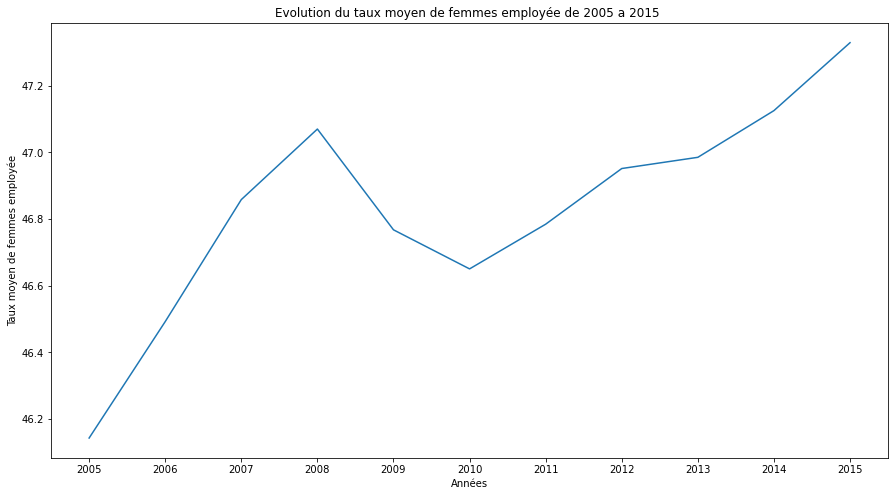

```python
#Dans cette cellule je vais visualiser l'evolution du taux de femmes employée de 2005 a 2015
title = 'Evolution du taux moyen de femmes employée de 2005 a 2015 '
xlabel = 'Années'
ylabel ='Taux moyen de femmes employée'
lineplot (labels,df_mean_femme_employee.femme_employée,title,xlabel,ylabel)
```

#### Question1 : phase 2

> Je vais maintenant voir si le taux moyen de femmes employé qui a augmenter en 2015 par rapport a 2005 est liée ou pas au fait que plus de pays en leurs taux superieur a la moyenne

> Dans cette section je vais comparer le nombre de pays avec un taux élevè et un taux bad de femme employée de 2005 a 2015.

> Les 2 catégories sont les suivantes :
> - Taux faible : inferieur au mean du taux de femme employée en 2005
> - Taux élevè : superieur au mean du taux de femme employée en 2005

```python
#récuperer le nombre de pays avec un taux inferieur au mean de 2005 et superieur au mean de 2005 pour chaque année
Taux_faible = df_females_employment.query('femme_employée < 46.142381').groupby(['years'])['country'].count().values
Taux_élevè = df_females_employment.query('femme_employée >=46.142381').groupby(['years'])['country'].count().values
Taux_élevè
```

```
array([ 93,  97, 101, 103, 101, 101, 100, 103, 104, 108, 109], dtype=int64)
```

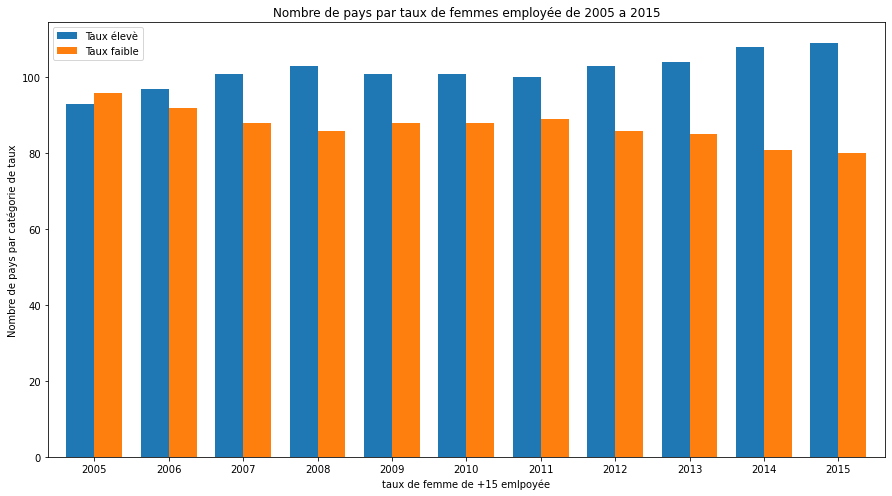

```python
#Je plote le nombre de pays avec un taux élevè et un taux faible par année
plt.figure(figsize=(20,10))
df = pd.DataFrame({'Taux élevè': Taux_élevè,
                  'Taux faible': Taux_faible}, index=labels)
df.plot(kind='bar', width=0.75, linewidth=3, figsize=(15,8),  xlabel = "taux de femme de +15 emlpoyée"
            ,ylabel = "Nombre de pays par catégorie de taux",rot=0, title="Nombre de pays par taux de femmes employée de 2005 a 2015")
plt.show()
```

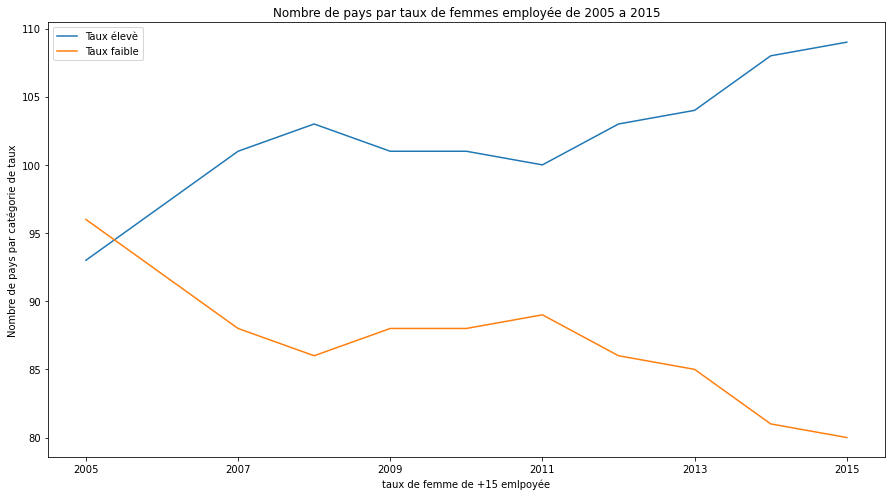

```python
plt.figure(figsize=(20,10))
df = pd.DataFrame({'Taux élevè': Taux_élevè,
                  'Taux faible': Taux_faible}, index=labels)
df.plot(kind='line', figsize=(15,8),  xlabel = "taux de femme de +15 emlpoyée"
            ,ylabel = "Nombre de pays par catégorie de taux",rot=0, title="Nombre de pays par taux de femmes employée de 2005 a 2015")
plt.show()
```

#### Conlusion question 1

A partir des de mini études sur la question 1 nous pouvons en conclure que le taux de femme employé augmente et nous pouvons supposé que depuis 2005 plus de pays emploie les femmes.

### Research Question 2 (Le taux de femmes qui travail affect-il le taux moyen de mort natale?)

```python
df_newborn_mortality.groupby('years').describe()
```

| years | mortalité_natale count | mortalité_natale mean | mortalité_natale std | mortalité_natale min | mortalité_natale 25% | mortalité_natale 50% | mortalité_natale 75% | mortalité_natale max |
| --- | --- | --- | --- | --- | --- | --- | --- | --- |
| 2005 | 195.0 | 17.678974 | 13.662871 | 1.0 | 5.70 | 13.8 | 27.50 | 56.1 |
| 2006 | 195.0 | 17.215897 | 13.401246 | 1.0 | 5.55 | 13.3 | 26.45 | 55.5 |
| 2007 | 195.0 | 16.771795 | 13.145956 | 1.0 | 5.50 | 12.6 | 25.60 | 55.0 |
| 2008 | 195.0 | 16.347179 | 12.893194 | 0.9 | 5.40 | 12.7 | 24.90 | 54.1 |
| 2009 | 195.0 | 15.931795 | 12.641823 | 0.9 | 5.15 | 12.1 | 24.90 | 53.4 |
| 2010 | 195.0 | 15.538462 | 12.413179 | 0.8 | 5.05 | 11.7 | 24.45 | 52.6 |
| 2011 | 195.0 | 15.126154 | 12.159019 | 0.8 | 4.95 | 11.4 | 24.00 | 51.9 |
| 2012 | 195.0 | 14.728718 | 11.921781 | 0.8 | 4.70 | 11.0 | 23.40 | 51.1 |
| 2013 | 195.0 | 14.343077 | 11.698233 | 0.7 | 4.50 | 10.6 | 22.85 | 50.4 |
| 2014 | 195.0 | 13.967179 | 11.472533 | 0.7 | 4.35 | 10.3 | 22.25 | 49.6 |
| 2015 | 195.0 | 13.606667 | 11.259640 | 0.7 | 4.25 | 9.8 | 21.75 | 48.7 |

```python
df_newborn_mortality
```

|  | country | years | mortalité_natale |
| --- | --- | --- | --- |
| 0 | Afghanistan | 2005 | 41.7 |
| 1 | India | 2005 | 38.3 |
| 2 | Switzerland | 2005 | 3.3 |
| 3 | Myanmar | 2005 | 33.5 |
| 4 | Ireland | 2005 | 3.0 |
| ... | ... | ... | ... |
| 2140 | Burkina Faso | 2015 | 26.7 |
| 2141 | Mali | 2015 | 37.8 |
| 2142 | Panama | 2015 | 9.6 |
| 2143 | Cote d'Ivoire | 2015 | 37.9 |
| 2144 | Zimbabwe | 2015 | 23.5 |

2145 rows × 3 columns

#### Question2 : phase 1

> Dans cette étape notre étude portera sur l'évolution du taux de mortalité natale de 2005 a 2015.

```python
#Pour commencer nous récupérons la moyenne du taux de femmes employée chaque année
df_mean_mortalite_natale = df_newborn_mortality.groupby('years', as_index=False)['mortalité_natale'].mean()
df_mean_mortalite_natale
```

|  | years | mortalité_natale |
| --- | --- | --- |
| 0 | 2005 | 17.678974 |
| 1 | 2006 | 17.215897 |
| 2 | 2007 | 16.771795 |
| 3 | 2008 | 16.347179 |
| 4 | 2009 | 15.931795 |
| 5 | 2010 | 15.538462 |
| 6 | 2011 | 15.126154 |
| 7 | 2012 | 14.728718 |
| 8 | 2013 | 14.343077 |
| 9 | 2014 | 13.967179 |
| 10 | 2015 | 13.606667 |

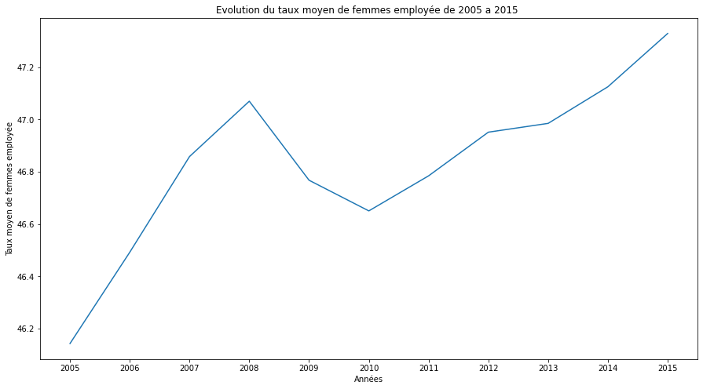

```python
#Dans cette cellule je vais visualiser l'evolution du taux de femmes employée de 2005 a 2015
title = 'Evolution du taux moyen de femmes employée de 2005 a 2015 '
xlabel = 'Années'
ylabel ='Taux moyen de femmes employée'
lineplot (labels,df_mean_femme_employee.femme_employée,title,xlabel,ylabel)
```

```python
#Dans cette cellule je vais visualiser l'evolution du taux de taux_moyen_mort_natale de 2005 a 2015
title = 'Evolution du taux moyen de mort natale de 2005 a 2015'
xlabel = 'Années'
ylabel ='Taux moyen de mort natale'
lineplot (labels,df_mean_mortalite_natale.mortalité_natale,title,xlabel,ylabel)
```

[output not shown]

#### conlusion phase 1 :

> De ce fait je peux supposer que le taux de femmes emlpoyé n'affecte pas la mortalité natale.

#### Question2 : phase 2

> Je vais efféctuer une recherche un petit peu plus approfondi pour voir si réellement le taux de femmes emloyé n'affecte vraiment pas le taux de mortalité. Je vais cela on comporant les pays avec un taux de femme emloyée inferieur a la moyenne et les pays avec un taux de femme employé superieur puis voir la courbe du taux de mortalité de ces 2 categorie

```python
df_females_employment.groupby('years').describe()
```

| years | femme_employée count | femme_employée mean | femme_employée std | femme_employée min | femme_employée 25% | femme_employée 50% | femme_employée 75% | femme_employée max |
| --- | --- | --- | --- | --- | --- | --- | --- | --- |
| 2005 | 189.0 | 46.142381 | 16.521626 | 9.01 | 36.3 | 45.8 | 57.0 | 84.5 |
| 2006 | 189.0 | 46.491905 | 16.465752 | 9.37 | 37.9 | 46.6 | 57.3 | 83.9 |
| 2007 | 189.0 | 46.858201 | 16.388537 | 10.60 | 37.8 | 47.5 | 58.0 | 83.5 |
| 2008 | 189.0 | 47.070000 | 16.329808 | 9.73 | 39.3 | 47.7 | 57.6 | 83.5 |
| 2009 | 189.0 | 46.767460 | 16.220755 | 8.85 | 37.9 | 47.0 | 56.9 | 83.3 |
| 2010 | 189.0 | 46.650159 | 16.109842 | 8.08 | 39.0 | 46.6 | 56.7 | 83.2 |
| 2011 | 189.0 | 46.784339 | 16.101442 | 7.04 | 38.9 | 47.0 | 56.9 | 84.8 |
| 2012 | 189.0 | 46.951481 | 16.027207 | 6.03 | 39.4 | 47.4 | 57.0 | 86.0 |
| 2013 | 189.0 | 46.985132 | 15.880182 | 5.19 | 39.2 | 47.7 | 55.8 | 84.8 |
| 2014 | 189.0 | 47.125344 | 15.809631 | 4.49 | 39.5 | 47.8 | 56.8 | 83.5 |
| 2015 | 189.0 | 47.329259 | 15.710120 | 4.53 | 39.9 | 48.3 | 56.4 | 82.9 |

```python
df_newborn_mortality
```

|  | country | years | mortalité_natale |
| --- | --- | --- | --- |
| 0 | Afghanistan | 2005 | 41.7 |
| 1 | India | 2005 | 38.3 |
| 2 | Switzerland | 2005 | 3.3 |
| 3 | Myanmar | 2005 | 33.5 |
| 4 | Ireland | 2005 | 3.0 |
| ... | ... | ... | ... |
| 2140 | Burkina Faso | 2015 | 26.7 |
| 2141 | Mali | 2015 | 37.8 |
| 2142 | Panama | 2015 | 9.6 |
| 2143 | Cote d'Ivoire | 2015 | 37.9 |
| 2144 | Zimbabwe | 2015 | 23.5 |

2145 rows × 3 columns

```python
#Cette fonction permet de récuperer les pays de chaque année par rapport au taux a étudier si il est supereieur ou inferieur a mean
def pays_par_taux_annee(database,condition_value,column_etudier) :
    condition = '{}<{}'
    taux_faible = database.query(condition.format(column_etudier,condition_value))
    condition = '{}>={}'
    taux_élevè = database.query(condition.format(column_etudier,condition_value))
    return taux_faible, taux_élevè
```

```python
#fonction qui calcule le taux pour chaque année et je merge avec le taux de mortalité natale
#cette fonction retourn un dataframe qui comporte le mean de chaque année du taux de mortalité natale
def calcul_taux_annee(dataframe1):
    df_mean_merge = pd.merge(dataframe1, df_newborn_mortality, how='left', left_on=['country','years'], right_on = ['country','years'] )
    mortalité_categorie = df_mean_merge.groupby('years', as_index=True)['mortalité_natale'].mean().values.tolist()
    return mortalité_categorie
```

```python
#Je vais maintenant récuperer les pays avec un taux de femmes employée superieur a mean et calculer le mean par categorie
femme_employée_faible,femme_employée_élevè = pays_par_taux_annee(df_females_employment,46.142381,'femme_employée')
mortalité_natale_faible = calcul_taux_annee(femme_employée_faible)
mortalité_natale_élevè = calcul_taux_annee(femme_employée_élevè)
```

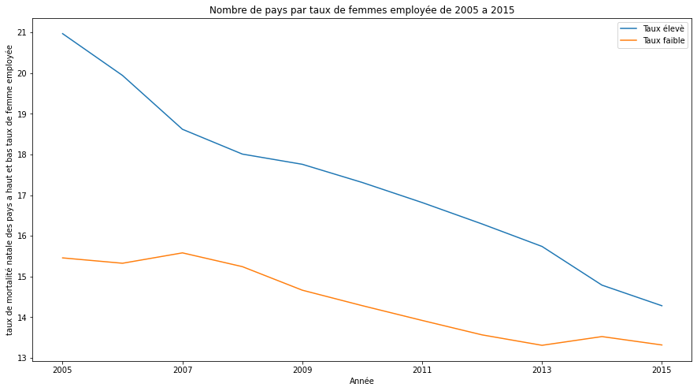

```python
plt.figure(figsize=(20,10))
df = pd.DataFrame({'Taux élevè': mortalité_natale_élevè,
                  'Taux faible': mortalité_natale_faible}, index=labels)
df.plot(kind='line', figsize=(15,8),  xlabel = "Année"
            ,ylabel = "taux de mortalité natale des pays a haut et bas taux de femme employée",rot=0, title="Nombre de pays par taux de femmes employée de 2005 a 2015")
plt.show()
```

#### conlusion phase 2 :

> De ce diagrame en peux remarqué que les pays a taux élevè de femmes employée ont un taux de mortalité qui baisse de **2005 a 2015**.

> en ce qui concerne les pays avec un taux faible de femme employée on peux remarquer que de **2006 a 2007** le taux de mortalité natale augment **0.255387** qui n'est pas d'une très grande difference. le taux baisse de nouveau en **2007** pour augmenté une nouvelle fois **2013 a 2014** d'un taux de **0.214603** pour baissé l'année suivante et atteindre un taux de **13.318182**

### Research Question 3 (Le taux de mortalité natal a t-il une relation avec les acouchements non supervisé par des pro)

```python
df_newborn_mortality.groupby('years').describe()
```

| years | mortalité_natale count | mortalité_natale mean | mortalité_natale std | mortalité_natale min | mortalité_natale 25% | mortalité_natale 50% | mortalité_natale 75% | mortalité_natale max |
| --- | --- | --- | --- | --- | --- | --- | --- | --- |
| 2005 | 195.0 | 17.678974 | 13.662871 | 1.0 | 5.70 | 13.8 | 27.50 | 56.1 |
| 2006 | 195.0 | 17.215897 | 13.401246 | 1.0 | 5.55 | 13.3 | 26.45 | 55.5 |
| 2007 | 195.0 | 16.771795 | 13.145956 | 1.0 | 5.50 | 12.6 | 25.60 | 55.0 |
| 2008 | 195.0 | 16.347179 | 12.893194 | 0.9 | 5.40 | 12.7 | 24.90 | 54.1 |
| 2009 | 195.0 | 15.931795 | 12.641823 | 0.9 | 5.15 | 12.1 | 24.90 | 53.4 |
| 2010 | 195.0 | 15.538462 | 12.413179 | 0.8 | 5.05 | 11.7 | 24.45 | 52.6 |
| 2011 | 195.0 | 15.126154 | 12.159019 | 0.8 | 4.95 | 11.4 | 24.00 | 51.9 |
| 2012 | 195.0 | 14.728718 | 11.921781 | 0.8 | 4.70 | 11.0 | 23.40 | 51.1 |
| 2013 | 195.0 | 14.343077 | 11.698233 | 0.7 | 4.50 | 10.6 | 22.85 | 50.4 |
| 2014 | 195.0 | 13.967179 | 11.472533 | 0.7 | 4.35 | 10.3 | 22.25 | 49.6 |
| 2015 | 195.0 | 13.606667 | 11.259640 | 0.7 | 4.25 | 9.8 | 21.75 | 48.7 |

```python
df_health_staff.shape
```

```
(1195, 3)
```

#### Question3 : phase 1

> Dans cette étape notre étude portera sur l'évolution du taux_moyen_naissance_supervisé de 2005 a 2015.

```python
#Pour commencer nous récupérons la moyenne du taux de health_staff chaque année
df_mean_health_staff = df_health_staff.groupby('years', as_index=False)['health_staff'].mean()
df_mean_health_staff
```

|  | years | health_staff |
| --- | --- | --- |
| 0 | 2005 | 89.169725 |
| 1 | 2006 | 83.588095 |
| 2 | 2007 | 90.789908 |
| 3 | 2008 | 91.192381 |
| 4 | 2009 | 93.025962 |
| 5 | 2010 | 87.270940 |
| 6 | 2011 | 90.112500 |
| 7 | 2012 | 91.542056 |
| 8 | 2013 | 91.365049 |
| 9 | 2014 | 92.153913 |
| 10 | 2015 | 93.225000 |

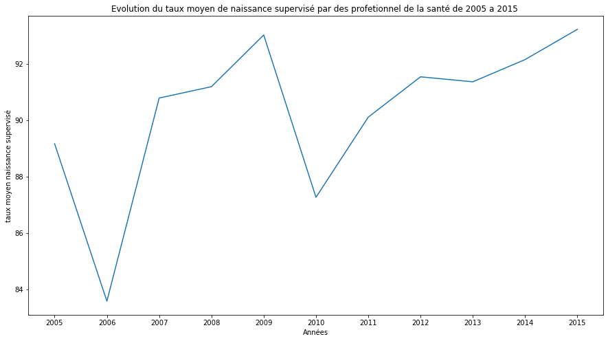

```python
#Dans cette cellule je vais visualiser l'evolution du taux moyen de naissance supervisé par des profetionnel de la santé
title = 'Evolution du taux moyen de naissance supervisé par des profetionnel de la santé de 2005 a 2015 '
xlabel = 'Années'
ylabel ='taux moyen naissance supervisé'
lineplot (labels,df_mean_health_staff.health_staff,title,xlabel,ylabel)
```

```python
#Dans cette cellule je vais visualiser l'evolution du ttaux moyen de mort natale de 2005 a 2015
title = 'Evolution du taux moyen de mort natale de 2005 a 2015'
xlabel = 'Années'
ylabel ='Taux moyen de mort natale'
lineplot (labels,df_mean_mortalite_natale.mortalité_natale,title,xlabel,ylabel)
```

[output not shown]

#### conlusion phase 1 :

> de **2006 a 2009** le taux moyen de naissance supervisé par des profetionnel a augmente un peu de **83.588095 a 93.025962** durant cette période le taux de mortalité natale continue de baissé il atteint en **2009** un taux de **15.931795**

> de **2009 a 2010** le taux moyen de naissance supervisé par des profetionnel baisse de nouveau, il atteint un taux de **87.270940** quant aux taux de mortalité natale, il continue a baisse il atteint en **2010** un taux de **15.538462**

> De **2010 a 2015** le taux moyen de naissance supervisé par des profetionnel augmente a nouveaut et atteint un taux de **93.225000** ne pouvons pas savoir si le taux de naissance supervisé affect ou pas le taux de mortalité une étude un peu plus appronfondie doit être faite.

##### Question3 pahse 2

```python
df_health_staff.describe()
```

|  | years | health_staff |
| --- | --- | --- |
| count | 1195.000000 | 1195.000000 |
| mean | 2009.897071 | 90.153054 |
| std | 3.161263 | 18.507321 |
| min | 2005.000000 | 5.700000 |
| 25% | 2007.000000 | 91.500000 |
| 50% | 2010.000000 | 98.800000 |
| 75% | 2013.000000 | 99.800000 |
| max | 2015.000000 | 100.000000 |

```python
#Je vais maintenant récuperer les pays avec un taux de health_staff superieur a mean et calculer le mean par categorie
health_staff_faible,health_staff_élevè = pays_par_taux_annee(df_health_staff,89.169725,'health_staff')
mortalité_natale_faible = calcul_taux_annee(health_staff_faible)
mortalité_natale_élevè = calcul_taux_annee(health_staff_élevè)
health_staff = health_staff_élevè.groupby('years')['health_staff'].mean().values.tolist()
```

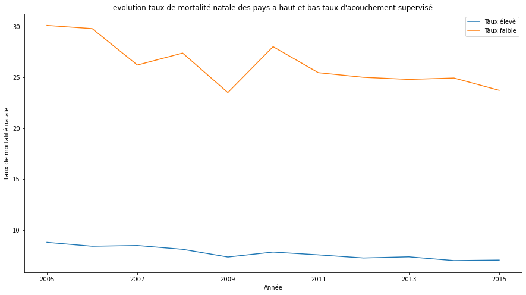

```python
plt.figure(figsize=(20,10))
df = pd.DataFrame({'Taux élevè': mortalité_natale_élevè,
                  'Taux faible': mortalité_natale_faible}, index=labels)
df.plot(kind='line', figsize=(15,8),  xlabel = "Année"
            ,ylabel = "taux de mortalité natale",rot=0, title="evolution taux de mortalité natale des pays a haut et bas taux d'acouchement supervisé")
plt.show()
```

#### conlusion phase 2 :

> De ce diagrame en peux remarqué que les pays a taux élevè d'acouchement supervisé par du personnel medical a un taux clairement plus faible de mortalité natale.

> de **2005 a 2009** le taux de mortalité natale dans les pays a faible acouchement supervisé baisse de **30.12 a 23.51** en ce qui concerne les pays avec un taux élevè on remarque également une baisse jusqu'a **2009**.

> de **2009 2010** une augmentation du taux de mortalité natale est remarqué chez les pays a taux faible d'acouchement superivé. Le taux passe de **23.51 a 28.02** en remarque a la meme periode une augmentation du taux de mortalité chez l'aure catégorie mais elle est legere et baisse rapidement pour atteindre 7.03 en 2015.

> de **2010 a 2015** un baisse est encore une fois remarque chez les pays a taux faible d'acouchement supervié le taux passe de **28.02 a 23.73**

> De cette analyse je peux supposer que le taux de mortalité natale est liée au taux d'acouchement supervisé par un staff medical car le taux de mortalité natale chez les pays a taux élevè d'acouchement supervisé est tres faible.

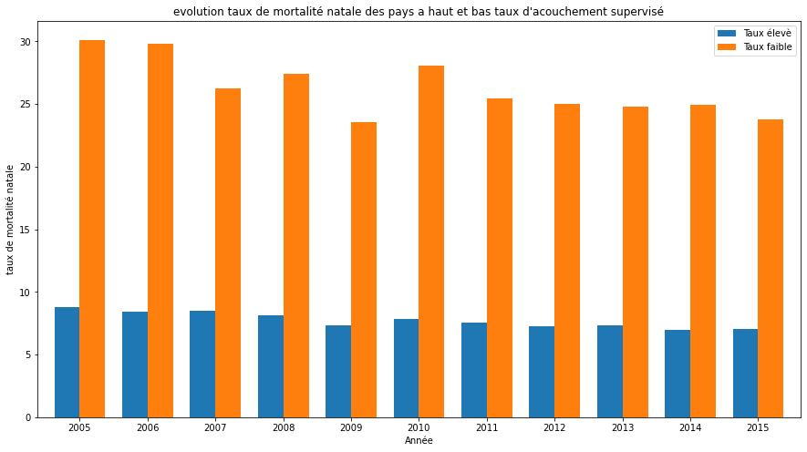

```python
plt.figure(figsize=(20,10))
df = pd.DataFrame({'Taux élevè': mortalité_natale_élevè,
                  'Taux faible': mortalité_natale_faible}, index=labels)
df.plot(kind='bar', width=0.75, linewidth=3, figsize=(15,8),  xlabel = "Année"
            ,ylabel = "taux de mortalité natale",rot=0, title="evolution taux de mortalité natale des pays a haut et bas taux d'acouchement supervisé")
plt.show()
```

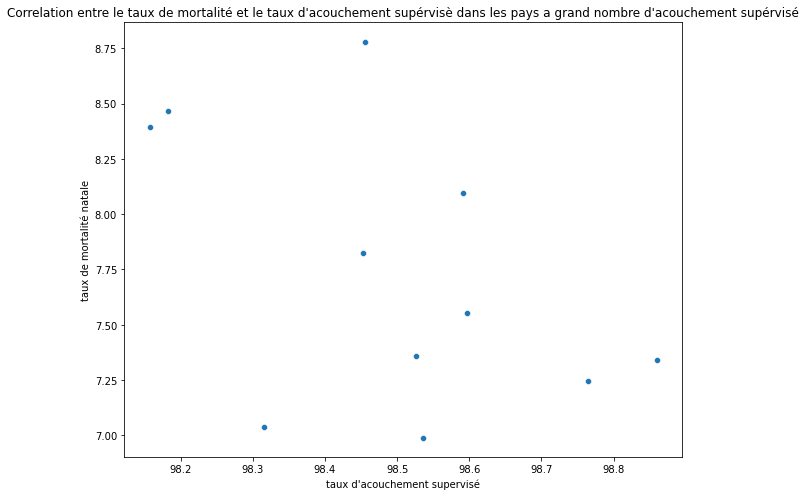

```python
#nous allons ici testé la correlation entre le taux de mortalité natale en 2015 et le taux d'acouchement supérvisè dans les pays a grand nombre d'acouchement supérvisé
plt.figure(figsize=(10,8))
sns.scatterplot(x = health_staff, y = mortalité_natale_élevè)
plt.title("Correlation entre le taux de mortalité et le taux d'acouchement supérvisè dans les pays a grand nombre d'acouchement supérvisé")
plt.xlabel("taux d'acouchement supervisé")
plt.ylabel("taux de mortalité natale")
plt.show()
```

```python
#Caluculer le coéfficient de correlation
arr_health_staff = np.array(health_staff)
arr_mortalité_natale_élevè = np.array(mortalité_natale_élevè)
r = np.corrcoef(arr_health_staff, arr_mortalité_natale_élevè)
r
```

```
array([[ 1.      , -0.500957],
       [-0.500957,  1.      ]])
```

#### conclusin

> Nous pouvons remarqué de ce graphe que la correlation entre le taux de mortalité natale et le taux d'acouchement supervisé par un personnel médical est une correlation négative est de ce fais les 2 variable sont liée mais en calculant le coéfficient de corrélaion on obtien un resultat de -0.50 ce qui fait ce qui ont fait une corrélation faible et donc les 2 variable ne sont pas liée, mais cela peut etre du au manque de donnée et au fait que j'ai supprimer les valeur null qui ce trouvais dans cette base de donnée. Une étude avec plus de données et moins de valeurs manquante nous donnerais une meilleure vu sur la relation entre ces 2 attribut.

### Research Question 4 (Un taux de mortalité Maternel élevè affect-il le taux de mortalité natale?)

```python
df_newborn_mortality.groupby('years').describe()
```

| years | mortalité_natale count | mortalité_natale mean | mortalité_natale std | mortalité_natale min | mortalité_natale 25% | mortalité_natale 50% | mortalité_natale 75% | mortalité_natale max |
| --- | --- | --- | --- | --- | --- | --- | --- | --- |
| 2005 | 195.0 | 17.678974 | 13.662871 | 1.0 | 5.70 | 13.8 | 27.50 | 56.1 |
| 2006 | 195.0 | 17.215897 | 13.401246 | 1.0 | 5.55 | 13.3 | 26.45 | 55.5 |
| 2007 | 195.0 | 16.771795 | 13.145956 | 1.0 | 5.50 | 12.6 | 25.60 | 55.0 |
| 2008 | 195.0 | 16.347179 | 12.893194 | 0.9 | 5.40 | 12.7 | 24.90 | 54.1 |
| 2009 | 195.0 | 15.931795 | 12.641823 | 0.9 | 5.15 | 12.1 | 24.90 | 53.4 |
| 2010 | 195.0 | 15.538462 | 12.413179 | 0.8 | 5.05 | 11.7 | 24.45 | 52.6 |
| 2011 | 195.0 | 15.126154 | 12.159019 | 0.8 | 4.95 | 11.4 | 24.00 | 51.9 |
| 2012 | 195.0 | 14.728718 | 11.921781 | 0.8 | 4.70 | 11.0 | 23.40 | 51.1 |
| 2013 | 195.0 | 14.343077 | 11.698233 | 0.7 | 4.50 | 10.6 | 22.85 | 50.4 |
| 2014 | 195.0 | 13.967179 | 11.472533 | 0.7 | 4.35 | 10.3 | 22.25 | 49.6 |
| 2015 | 195.0 | 13.606667 | 11.259640 | 0.7 | 4.25 | 9.8 | 21.75 | 48.7 |

```python
df_mmr_who.groupby('years').describe()
```

| years | mortalité_maternel count | mortalité_maternel mean | mortalité_maternel std | mortalité_maternel min | mortalité_maternel 25% | mortalité_maternel 50% | mortalité_maternel 75% | mortalité_maternel max |
| --- | --- | --- | --- | --- | --- | --- | --- | --- |
| 2005.0 | 184.0 | 231.320652 | 324.549659 | 3.0 | 18.75 | 70.5 | 348.75 | 1760.0 |
| 2006.0 | 184.0 | 221.793478 | 311.576234 | 2.0 | 18.00 | 65.5 | 333.25 | 1680.0 |
| 2007.0 | 184.0 | 213.010870 | 299.335785 | 2.0 | 16.75 | 63.5 | 310.00 | 1610.0 |
| 2008.0 | 184.0 | 205.739130 | 289.407171 | 2.0 | 17.25 | 65.0 | 295.25 | 1530.0 |
| 2009.0 | 184.0 | 199.141304 | 279.692418 | 2.0 | 17.50 | 64.0 | 281.75 | 1450.0 |
| 2010.0 | 184.0 | 192.309783 | 270.393231 | 2.0 | 16.50 | 64.0 | 270.25 | 1360.0 |
| 2011.0 | 184.0 | 186.244565 | 262.389566 | 2.0 | 15.00 | 57.5 | 262.25 | 1270.0 |
| 2012.0 | 184.0 | 181.217391 | 256.116727 | 2.0 | 16.75 | 58.0 | 254.00 | 1210.0 |
| 2013.0 | 184.0 | 176.961957 | 252.600407 | 2.0 | 15.50 | 58.0 | 240.50 | 1180.0 |
| 2014.0 | 184.0 | 173.695652 | 250.047831 | 2.0 | 14.50 | 58.0 | 225.00 | 1190.0 |
| 2015.0 | 184.0 | 169.010870 | 243.272093 | 2.0 | 13.75 | 56.0 | 220.75 | 1180.0 |

```python
#Pour commencer nous récupérons la moyenne du taux de mmr_who chaque année
df_mean_mmr_who = df_mmr_who.groupby('years', as_index=False)['mortalité_maternel'].mean()
df_mean_mmr_who
```

|  | years | mortalité_maternel |
| --- | --- | --- |
| 0 | 2005.0 | 231.320652 |
| 1 | 2006.0 | 221.793478 |
| 2 | 2007.0 | 213.010870 |
| 3 | 2008.0 | 205.739130 |
| 4 | 2009.0 | 199.141304 |
| 5 | 2010.0 | 192.309783 |
| 6 | 2011.0 | 186.244565 |
| 7 | 2012.0 | 181.217391 |
| 8 | 2013.0 | 176.961957 |
| 9 | 2014.0 | 173.695652 |
| 10 | 2015.0 | 169.010870 |

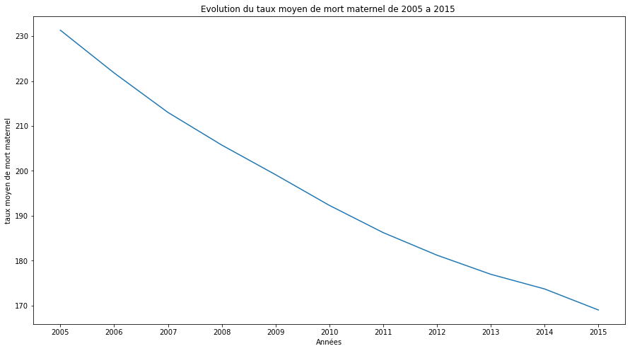

```python
#Dans cette cellule je vais visualiser l'evolution du taux moyen de mort maternel de 2005 a 2015
title = 'Evolution du taux moyen de mort maternel de 2005 a 2015 '
xlabel = 'Années'
ylabel ='taux moyen de mort maternel'
lineplot (labels,df_mean_mmr_who.mortalité_maternel,title,xlabel,ylabel)
```

```python
title = 'Evolution du taux moyen de mort natale de 2005 a 2015'
xlabel = 'Années'
ylabel ='Taux moyen de mort natale'
lineplot (labels,df_mean_mortalite_natale.mortalité_natale,title,xlabel,ylabel)
```

#### conlusion:

> de 2005 a 2015 nous remarqu'on que le taux de mortalité maternel baisse de **231.320652 a 169.010870** cela est de meme pour le taux moyen de mort natale, nous pouvons supposé que ces de variable sont liée. Nous allons éxploré cette supposition un peu plus.

```python
df_mmr_who.groupby('years').describe()
```

| years | mortalité_maternel count | mortalité_maternel mean | mortalité_maternel std | mortalité_maternel min | mortalité_maternel 25% | mortalité_maternel 50% | mortalité_maternel 75% | mortalité_maternel max |
| --- | --- | --- | --- | --- | --- | --- | --- | --- |
| 2005.0 | 184.0 | 231.320652 | 324.549659 | 3.0 | 18.75 | 70.5 | 348.75 | 1760.0 |
| 2006.0 | 184.0 | 221.793478 | 311.576234 | 2.0 | 18.00 | 65.5 | 333.25 | 1680.0 |
| 2007.0 | 184.0 | 213.010870 | 299.335785 | 2.0 | 16.75 | 63.5 | 310.00 | 1610.0 |
| 2008.0 | 184.0 | 205.739130 | 289.407171 | 2.0 | 17.25 | 65.0 | 295.25 | 1530.0 |
| 2009.0 | 184.0 | 199.141304 | 279.692418 | 2.0 | 17.50 | 64.0 | 281.75 | 1450.0 |
| 2010.0 | 184.0 | 192.309783 | 270.393231 | 2.0 | 16.50 | 64.0 | 270.25 | 1360.0 |
| 2011.0 | 184.0 | 186.244565 | 262.389566 | 2.0 | 15.00 | 57.5 | 262.25 | 1270.0 |
| 2012.0 | 184.0 | 181.217391 | 256.116727 | 2.0 | 16.75 | 58.0 | 254.00 | 1210.0 |
| 2013.0 | 184.0 | 176.961957 | 252.600407 | 2.0 | 15.50 | 58.0 | 240.50 | 1180.0 |
| 2014.0 | 184.0 | 173.695652 | 250.047831 | 2.0 | 14.50 | 58.0 | 225.00 | 1190.0 |
| 2015.0 | 184.0 | 169.010870 | 243.272093 | 2.0 | 13.75 | 56.0 | 220.75 | 1180.0 |

```python
#Je vais maintenant récuperer les pays avec un taux de mmr_who superieur a mean et calculer le mean par categorie
mmr_who_faible,mmr_who_élevè = pays_par_taux_annee(df_mmr_who,231.320652,'mortalité_maternel')
mortalité_natale_faible = calcul_taux_annee(mmr_who_faible)
mortalité_natale_élevè = calcul_taux_annee(mmr_who_élevè)
mmr_who = mmr_who_élevè.groupby('years')['mortalité_maternel'].mean().values.tolist()
```

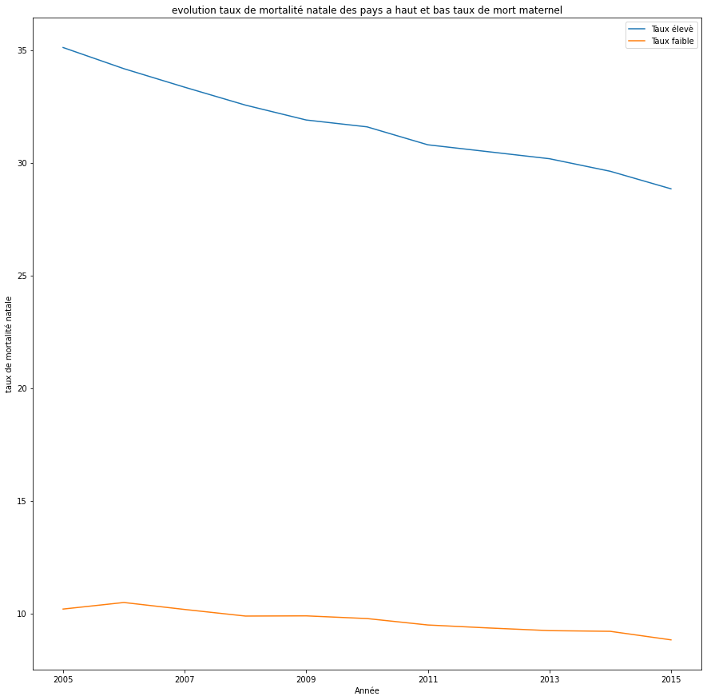

```python
plt.figure(figsize=(35,10))
df = pd.DataFrame({'Taux élevè': mortalité_natale_élevè,
                  'Taux faible': mortalité_natale_faible}, index=labels)
df.plot(kind='line', figsize=(15,15),  xlabel = "Année"
            ,ylabel = "taux de mortalité natale",rot=0, title="evolution taux de mortalité natale des pays a haut et bas taux de mort maternel")
plt.show()
```

#### conlusion:

> Nous pouvons conclure de ce graphe que dans les pays ou le taux de mortalité natale est élevè le taux de mortalité natale l'ai également contrairement au pays ou le temps de mortalité maternel est faible nous pouvons remarqué que le taux de mortalité natale est faible, nous pouvons également remarqué que dans les de cas (pays a taux de mortalité maternel et pays a taux de mortalité faible) le taux de mortalité natale baisse, cela pourrait etre du au fait que beaucoup plus d'acouchement sont supervisé par du personnel medical et de ce fait diminue le taux de mortalité natale.

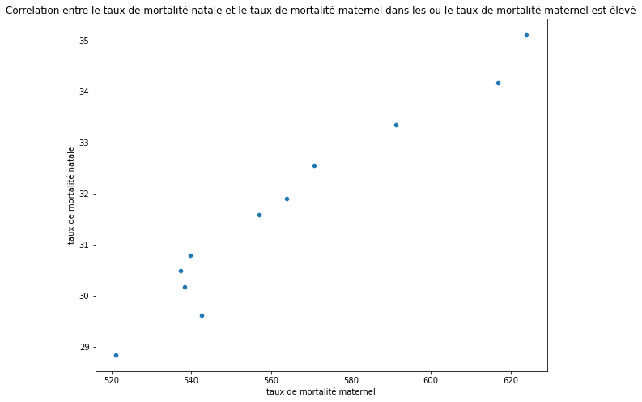

```python
#nous allons ici testé la correlation entre le taux de mortalité natale en 2015 et le taux de mortalité maternel des pays ou le taux de mortalité maternel est élevè
plt.figure(figsize=(10,8))
sns.scatterplot(x = mmr_who, y = mortalité_natale_élevè)
plt.title("Correlation entre le taux de mortalité natale et le taux de mortalité maternel dans les ou le taux de mortalité maternel est élevè")
plt.xlabel("taux de mortalité maternel")
plt.ylabel("taux de mortalité natale")
plt.show()
```

```python
#Caluculer le coéfficient de correlation
arr_mmr_who = np.array(mmr_who)
arr_mortalité_natale_élevè = np.array(mortalité_natale_élevè)
r = np.corrcoef(arr_mmr_who, arr_mortalité_natale_élevè)
r
```

```
array([[1.        , 0.97539453],
       [0.97539453, 1.        ]])
```

#### conclusin

> Nous pouvons remarqué de ce graphe que la correlation entre le taux de mortalité natale et le taux de mortalité maternel est une correlation positive est de ce fais les 2 variable sont liée l'une a l'autre, et le coéfficient de corrélation **0.97** nous prove une forte relation entre ces 2 attributs

## recherches supplémentaires

> Une étude sur la possibilité que les guerres et les problemes économique peuvent affecter le taux de mortalité. Une étude plus approfondie sur si le taux d'acouchement supervisé est liée au infrastructure médical du pays

# Remarque

> pour certaine petite question comme par exemple comment transformer un int ou float et comment merge les données comment faire un plot j'ai utilisé le site de pandas et stackoverflow